# 하루라도.. 최저가에 사고 싶다. 데이터 수집편

데이터스토리 [하루라도..최저가에 사고 싶다]에서 사용된 데이터를 어떻게 수집하였는지 설명하려고 한다.

혹시라도 [데이터스토리](https://core.today/story/view/e6d6e7cf-40f7-41d3-81b7-255d48877950)를 읽지 않은 분은 링크타고 읽고 오길 바란다.

어떻게 활용할 데이터인지 알면 이번에 설명할 데이터 수집방법을 조금 더 쉽게 이해할 수 있다고 생각한다.

## 목표 : 기업의 시간별 시세 데이터를 수집할 수 있다.

### 데이터 위치

시간별 시세 데이터는 [네이버금융](https://finance.naver.com/main/main.nhn)에서 수집하였다. 상세한 위치는 **[네이버 금융 > 회사명 입력 > 시세 > 시간대별 시세]** 이다.

데이터 위치는 설명했고 이제는 데이터 수집방법을 설명하겠다. 일단 현재 페이지 HTML구조 파악이 먼저다.

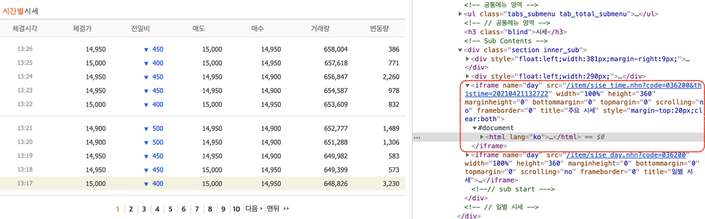

### HTML 구조 파악

HTML 구조를 보니깐 Iframe 태그에 시간대별 시세 데이터가 담겨있다.

Iframe에 대해 간단히 설명하자면 다른 HTML 페이지를 현재 페이지에 포함시킨다라는 의미다.

보통, `<iframe src="삽입할페이지주소" width="너비" height="높이"></iframe>` << 이렇게 쓰인다.

네이버 금융 도메인 주소에 `/item/sise_time.nhn?code=036200&thistime=20210421132722`을 붙이면 시간별 시세가 담겨 있는 웹페이지 주소가 완성된다!

URL : https://finance.naver.com/item/sise_time.nhn?code=036200&thistime=20210421132722 << 못 믿겠으면 클릭해보시길..

### URL 파라미터 파악

완성된 URL를 살펴보자. 파라미터로 `code`와 `thistime`을 가지고 있다.

`code`는 종목코드를 의미하고 `thistime`은 현재시각(웹페이지에 접속한 시간)을 의미한다.

[figure not shown]

끝이 아니다. 페이지를 변경하니 `page` 파라미터가 생긴다. 값으로 **페이지번호와 일치하는 숫자**를 가진다.

우리는 찾고 있는 기업의 종목코드, 웹페이지 접속 시각, 페이지번호를 바꿔가면서 데이터를 수집할 수 있다.

예를 들어, 삼성전자 종목코드 '005930', 접속시각을 '20210421180000', 페이지번호를 '9'로 바꿔 URL를 완성시키고

https://finance.naver.com/item/sise_time.nhn?code=005930&thistime=20210421180000&page=9

### 데이터 수집 코드 공개

```
############# 필요 라이브러리 ###############
from bs4 import BeautifulSoup as bs
from datetime import datetime, timedelta
from tqdm.notebook import tqdm
import requests
import pandas as pd
import os
#########################################
`
```

```
def get_code_df():
    '''
    기업명과 종목코드를 가지고 있는 데이터프레임을 생성한다.
    '''
    stock_code = pd.read_html('http://kind.krx.co.kr/corpgeneral/corpList.do?method=download', header=0)[0]

    # 필요한 것은 "회사명"과 "종목코드" 이므로 필요없는 column들은 제외
    stock_code = stock_code[['회사명', '종목코드']]

    # 종목코드가 6자리이기 때문에 6자리를 맞춰주기 위해 설정해줌
    stock_code.종목코드 = stock_code.종목코드.map('{:06d}'.format)
    return stock_code


def get_code(stock_code, corp_name):
    '''
    기업에 해당하는 종목코드를 반환해준다.
    '''
    code = stock_code.loc[stock_code.회사명 == corp_name, '종목코드'].item()
    return code


def get_soup(url):
    '''
    beautifulsoup로 해당 URL의 HTML을 수집해온다.
    '''
    header = {'user-agent': 'Mozilla/5.0'} # 헤더에 user-agent 를 넣어주지 않으면.. 데이터 수집이 안됨.
    res = requests.get(url, headers=header)
    soup = bs(res.text, 'html.parser')
    return soup


def get_df(rows):
    '''
    체결시각과 체결가컬럼을 데이터프레임을 반환한다.
    '''
    df = pd.DataFrame()
    for idx, row in enumerate(rows):
        time = row.find('td', align='center')
        if time:
            df.loc[idx, '체결시각'] = time.text

        price = row.find('td', class_='num')
        if price:
            df.loc[idx, '체결가'] = price.text

    df = df[df['체결시각'] != '\xa0'] # 공백을 제거.
    df = df.dropna().reset_index(drop=True) # NA값 제거
    return df


def crawl_price_data():
    '''
    시간별 시세 데이터를 수집해오는 함수다.
    '''
    stock_code = get_code_df()
    # 시가총액 TOP 5 기업리스트
    corp_list = ['삼성전자', 'SK하이닉스', 'NAVER', 'LG화학', '삼성바이오로직스']

    for corp in tqdm(corp_list):
        code = get_code(stock_code, corp)
        date = datetime.strftime(datetime.now(), '%Y%m%d%H%M%S') # 날짜시간
        df = pd.DataFrame() # 빈 데이터프레임 생성
        for num in range(1, 40): # 1~39 페이지
            url = f'https://finance.naver.com/item/sise_time.nhn?code={code}&thistime={date}&page={num}'
            soup = get_soup(url)

            table_sec = soup.find('table')
            rows = table_sec.find_all('tr')

            temp = get_df(rows)
            if len(temp) != 0:
                temp['일자'] = date[:8]
                df = pd.concat([df, temp], ignore_index=True)

        # 저장할 폴더 생성 및 csv 저장
        os.makedirs(f'./price_data/{corp}', exist_ok=True)
        file_name = datetime.strftime(datetime.now(), '%Y%m%d')
        df.to_csv(f'./price_data/{corp}/{file_name}.csv', encoding='utf8')
```

### 정해진 시간에 코드 자동으로 수행하기

- 라이브러리 schedule에 대한 설명이 나와있는 사이트
  - https://velog.io/@wltjs10645/Python-%EC%8B%A4%EC%8B%9C%EA%B0%84-%EC%9A%94%EC%B2%AD-%EC%9E%90%EB%8F%99%ED%99%94-scheduler

```
### 필요 라이브러리
import schedule
import time

### 스케쥴러
schedule.every().day.at("16:00").do(crawl_price_data) # 매일 16시 00분에 crawl_price_data 함수를 실행한다.

while True:
    schedue.run_pending()
    time.sleep(1)
```

컴퓨터 못끄는 단점이 있다.

끝.